# Customer Churn : Artificial Neural Networks

#### 3.12 Now we have new variables. So, splitting the dataset into the training set and test set

```python
from sklearn.model_selection import train_test_split

X_train, X_test, y_train, y_test = train_test_split(X, y, test_size = 0.2, random_state = 0)

#Oversampling
from imblearn.over_sampling import SMOTE
sm = SMOTE(random_state=12, ratio = 1.0)
X_train, y_train = sm.fit_sample(X_train, y_train)
```

#### 3.13 Again fitting ANN Classifier model on the important variables

```python
# Initialising the ANN
classifier = Sequential()

# Adding the input layer and the first hidden layer
classifier.add(Dense(units = 7, kernel_initializer = 'uniform', activation = 'relu', input_dim = 14))
classifier.add(Dropout(p = 0.3))

# Adding the second hidden layer
classifier.add(Dense(units = 7, kernel_initializer = 'uniform', activation = 'relu'))
classifier.add(Dropout(p = 0.3))

# Adding the output layer
classifier.add(Dense(units = 1, kernel_initializer = 'uniform', activation = 'sigmoid'))

# Compiling the ANN
classifier.compile(optimizer = 'adam', loss = 'binary_crossentropy', metrics = ['accuracy'])

# Fitting the ANN to the Training set
acc_plot = classifier.fit(X_train, y_train, batch_size = 10, epochs = 100,verbose=0,validation_data=(X_test,y_test))
```

- From previous run, we got to know that the model is overfitting the data. To reduce it, we are using Dropout value of **0.3**.

#### 3.14 Plotting loss and accuracy curve of training and test set

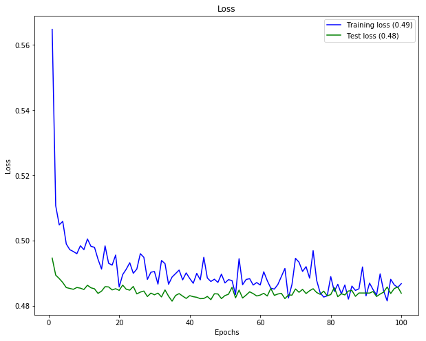

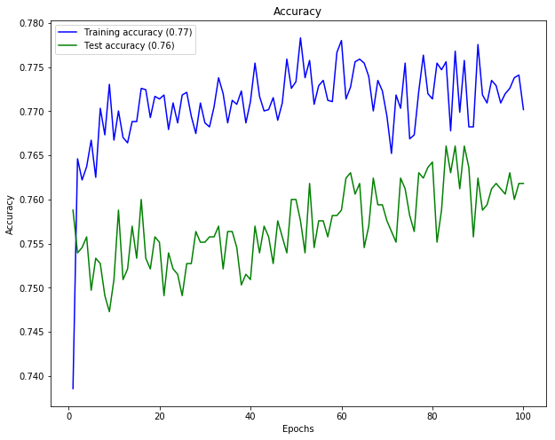

```python
plot_history(acc_plot)
```

- Overfitting has been reduced.

#### 3.15 Predicting the Test set results at a threshold of 0.5

```python
y_pred = classifier.predict(X_test)
y_pred = (y_pred > 0.5)
```

#### 3.16 Confusion Matrix

```python
from sklearn.metrics import confusion_matrix
cm = confusion_matrix(y_test, y_pred)
cm
```

```
array([[572, 235],
       [158, 685]], dtype=int64)
```

#### 3.17 Calculating accuracy of the model

```python
acc = ((cm[0,0]+cm[1,1])/(cm[0,0]+cm[0,1]+cm[1,0]+cm[1,1]))*100
print('Accuracy: {:.1f}'.format(acc))
```

```
Accuracy: 76.2
```

- Accuracy is low but good.

#### 3.18 Tuning the ANN using Grid Search

Grid search is used to get the best parameters for the model.

- **'batch_size':** Providing batch sizes to be tested.
- **'epochs':** Number of epochs to be tested.
- **'optimizer':** Optimizers to be tested.
- **cv:** cross validation set.

```python
from keras.wrappers.scikit_learn import KerasClassifier
from sklearn.model_selection import GridSearchCV

def build_classifier(optimizer):
    classifier = Sequential()
    classifier.add(Dense(units = 7, kernel_initializer = 'uniform', activation = 'relu', input_dim = 14))
    classifier.add(Dropout(p = 0.3))
    classifier.add(Dense(units = 7, kernel_initializer = 'uniform', activation = 'relu'))
    classifier.add(Dropout(p = 0.3))
    classifier.add(Dense(units = 1, kernel_initializer = 'uniform', activation = 'sigmoid'))
    classifier.compile(optimizer = optimizer, loss = 'binary_crossentropy', metrics = ['accuracy'])
    return classifier
classifier = KerasClassifier(build_fn = build_classifier)
parameters = {'batch_size': [25, 32],
              'epochs': [100, 500],
              'optimizer': ['adam', 'rmsprop']}
grid_search = GridSearchCV(estimator = classifier,
                           param_grid = parameters,
                           scoring = 'accuracy',
                           cv = 10)
grid_search = grid_search.fit(X_train, y_train,verbose=0)
```

##### Note: It will take about 3-4 hours on a standard PC having i7 processor and 8 GB of RAM.

#### 3.19 Printing the best parameters to be used in the model

```python
print("Best parameters: ",grid_search.best_params_)
print("Best accuracy: ",grid_search.best_score_)
```

```
Best parameters:  {'batch_size': 32, 'epochs': 500, 'optimizer': 'rmsprop'}
Best accuracy:  0.7906871609403255
```

#### 3.20 Feature Scaling

- This is used here only as a helper function for predicting new observations

```python
from sklearn.preprocessing import StandardScaler
sc = StandardScaler()
X_train = sc.fit_transform(X_train)
X_test = sc.transform(X_test)
```

#### 3.21 Fitting ANN Classifier model with best parameters

```python
import keras
from keras.models import Sequential
from keras.layers import Dense
from keras.layers import Dropout

# Initialising the ANN
classifier = Sequential()

# Adding the input layer and the first hidden layer
classifier.add(Dense(units = 7, kernel_initializer = 'uniform', activation = 'relu', input_dim = 14))
classifier.add(Dropout(p = 0.3))

# Adding the second hidden layer
classifier.add(Dense(units = 7, kernel_initializer = 'uniform', activation = 'relu'))
classifier.add(Dropout(p = 0.3))

# Adding the output layer
classifier.add(Dense(units = 1, kernel_initializer = 'uniform', activation = 'sigmoid'))

# Compiling the ANN
classifier.compile(optimizer = 'rmsprop', loss = 'binary_crossentropy', metrics = ['accuracy'])

# Fitting the ANN to the Training set
classifier.fit(X_train, y_train, batch_size = 32, epochs = 500,verbose=0)
```

#### 3.22 Predicting the Test set results at a threshold of 0.5

```python
y_pred = classifier.predict(X_test)
y_pred = (y_pred > 0.5)
```

#### 3.23 Confusion Matrix

```python
from sklearn.metrics import confusion_matrix
cm = confusion_matrix(y_test, y_pred)
cm
```

```
array([[574, 233],
       [134, 709]], dtype=int64)
```

#### 3.24 Calculating accuracy of the model

```python
acc = ((cm[0,0]+cm[1,1])/(cm[0,0]+cm[0,1]+cm[1,0]+cm[1,1]))*100
print('Accuracy: {:.1f}'.format(acc))
```

```
Accuracy: 77.8
```

#### 3.25 Plotting loss and accuracy curve of training and test set

[figure not shown]

[figure not shown]

```python
acc_plot = classifier.fit(X_train,
                    y_train,
                    epochs = 500,
                    batch_size = 32,
                    verbose=0,
                    validation_data=(X_test,y_test))
plot_history(acc_plot)
```

#### 3.26 k-fold-cross-validation

- Using 10 folds

```python
from keras.wrappers.scikit_learn import KerasClassifier
from sklearn.model_selection import cross_val_score

def build_classifier():
    classifier = Sequential()
    classifier.add(Dense(units = 12, kernel_initializer = 'uniform', activation = 'relu', input_dim = 23))
    classifier.add(Dense(units = 12, kernel_initializer = 'uniform', activation = 'relu'))
    classifier.add(Dense(units = 1, kernel_initializer = 'uniform', activation = 'sigmoid'))
    classifier.compile(optimizer = 'rmsprop', loss = 'binary_crossentropy', metrics = ['accuracy'])
    return classifier
classifier = KerasClassifier(build_fn = build_classifier, batch_size = 32, epochs = 500)
accuracies = cross_val_score(estimator = classifier, X = X_train, y = y_train, cv = 10, n_jobs = -1)
print("Mean: ",accuracies.mean())
print("Variance: ",accuracies.std())
```

[output not shown]

##### Note: It will take about 5-6 hours on a standard PC having i7 processor and 8 GB of RAM.

#### 3.27 Predicting new observations

- If False (0), then **No Churn**.
- If True (1), then it will be **Churn**.

```python
new_prediction = classifier.predict(sc.transform(np.array([[0, 0, 1, 0, 1, 1, 1, 1, 1, 0, 302, 0, 1, 1]])))
new_prediction = (new_prediction > 0.5)
print(new_prediction)

new_prediction = classifier.predict(sc.transform(np.array([[1, 0, 1, 0, 0, 1, 0, 1, 0, 0, 0, 0, 0, 1]])))
new_prediction = (new_prediction > 0.5)
print(new_prediction)
```

[output not shown]